# Capstone Project¶

USED CARS PRICE PREDICTION

# OBJECTIVE : Come up with a pricing model that can effectively predict the price of used cars and can help the business in devising profitable strategies using differential pricing.

DATA DICTIONARY

S.No. : Serial Number

Name : Name of the car which includes Brand name and Model name

Location : The location in which the car is being sold or is available for purchase (Cities)

Year : Manufacturing year of the car

Kilometers_driven : The total kilometers driven in the car by the previous owner(s) in KM

Fuel_Type : The type of fuel used by the car (Petrol, Diesel, Electric, CNG, LPG)

Transmission : The type of transmission used by the car (Automatic / Manual)

Owner : Type of ownership

Mileage : The standard mileage offered by the car company in kmpl or km/kg

Engine : The displacement volume of the engine in CC

Power : The maximum power of the engine in bhp

Seats : The number of seats in the car

New_Price : The price of a new car of the same model in INR 100,000

Price : The price of the used car in INR 100,000 (Target Variable)

IMPORTING LIBRARIES

```python
# import libraries for data manipulation
import numpy as np
import pandas as pd

# import libraries for data visualization
import matplotlib.pyplot as plt
import seaborn as sns
from statsmodels.graphics.gofplots import ProbPlot

# import libraries for building linear regression model
from statsmodels.formula.api import ols

import statsmodels.api as sm

from sklearn.linear_model import LinearRegression

# Import library for preparing data
from sklearn.model_selection import train_test_split

# Import library for data preprocessing
from sklearn.preprocessing import MinMaxScaler

import warnings
warnings.filterwarnings("ignore")

# Remove the limit from the number of displayed columns and rows. It helps to see the entire dataframe while printing it
pd.set_option("display.max_columns", None)
```

LOADING DATASET

```python
# read the dataset
df = pd.read_csv('C:\\Users\\Vedalie Goudou\\Desktop\\Applied Data Science\\Project 2\\used_cars.csv')
```

```python
df.head()
```

|  | S.No. | Name | Location | Year | Kilometers_Driven | Fuel_Type | Transmission | Owner_Type | Mileage | Engine | Power | Seats | New_price | Price |
| --- | --- | --- | --- | --- | --- | --- | --- | --- | --- | --- | --- | --- | --- | --- |
| 0 | 0 | Maruti Wagon R LXI CNG | Mumbai | 2010 | 72000 | CNG | Manual | First | 26.60 | 998.0 | 58.16 | 5.0 | NaN | 1.75 |
| 1 | 1 | Hyundai Creta 1.6 CRDi SX Option | Pune | 2015 | 41000 | Diesel | Manual | First | 19.67 | 1582.0 | 126.20 | 5.0 | NaN | 12.50 |
| 2 | 2 | Honda Jazz V | Chennai | 2011 | 46000 | Petrol | Manual | First | 18.20 | 1199.0 | 88.70 | 5.0 | 8.61 | 4.50 |
| 3 | 3 | Maruti Ertiga VDI | Chennai | 2012 | 87000 | Diesel | Manual | First | 20.77 | 1248.0 | 88.76 | 7.0 | NaN | 6.00 |
| 4 | 4 | Audi A4 New 2.0 TDI Multitronic | Coimbatore | 2013 | 40670 | Diesel | Automatic | Second | 15.20 | 1968.0 | 140.80 | 5.0 | NaN | 17.74 |

```python
df.info()
```

```
<class 'pandas.core.frame.DataFrame'>
RangeIndex: 7253 entries, 0 to 7252
Data columns (total 14 columns):
 #   Column             Non-Null Count  Dtype
---  ------             --------------  -----
 0   S.No.              7253 non-null   int64
 1   Name               7253 non-null   object
 2   Location           7253 non-null   object
 3   Year               7253 non-null   int64
 4   Kilometers_Driven  7253 non-null   int64
 5   Fuel_Type          7253 non-null   object
 6   Transmission       7253 non-null   object
 7   Owner_Type         7253 non-null   object
 8   Mileage            7251 non-null   float64
 9   Engine             7207 non-null   float64
 10  Power              7078 non-null   float64
 11  Seats              7200 non-null   float64
 12  New_price          1006 non-null   float64
 13  Price              6019 non-null   float64
dtypes: float64(6), int64(3), object(5)
memory usage: 793.4+ KB
```

```python
Observation : We have three different types of data in the database : Int64 (3), Object (5) and Float (6)
```

```python
df.nunique()
```

```
S.No.                7253
Name                 2041
Location               11
Year                   23
Kilometers_Driven    3660
Fuel_Type               5
Transmission            2
Owner_Type              4
Mileage               438
Engine                150
Power                 383
Seats                   8
New_price             625
Price                1373
dtype: int64
```

Observation : We can say that database is not complete ( missing values) and no clean.

```python
df.isnull()
```

|  | S.No. | Name | Location | Year | Kilometers_Driven | Fuel_Type | Transmission | Owner_Type | Mileage | Engine | Power | Seats | New_price | Price |
| --- | --- | --- | --- | --- | --- | --- | --- | --- | --- | --- | --- | --- | --- | --- |
| 0 | False | False | False | False | False | False | False | False | False | False | False | False | True | False |
| 1 | False | False | False | False | False | False | False | False | False | False | False | False | True | False |
| 2 | False | False | False | False | False | False | False | False | False | False | False | False | False | False |
| 3 | False | False | False | False | False | False | False | False | False | False | False | False | True | False |
| 4 | False | False | False | False | False | False | False | False | False | False | False | False | True | False |
| ... | ... | ... | ... | ... | ... | ... | ... | ... | ... | ... | ... | ... | ... | ... |
| 7248 | False | False | False | False | False | False | False | False | False | False | False | False | True | True |
| 7249 | False | False | False | False | False | False | False | False | False | False | False | False | True | True |
| 7250 | False | False | False | False | False | False | False | False | False | False | False | False | True | True |
| 7251 | False | False | False | False | False | False | False | False | False | False | False | False | True | True |
| 7252 | False | False | False | False | False | False | False | False | False | False | False | False | True | True |

7253 rows × 14 columns

```python
df.isnull().sum()
```

```
S.No.                   0
Name                    0
Location                0
Year                    0
Kilometers_Driven       0
Fuel_Type               0
Transmission            0
Owner_Type              0
Mileage                 2
Engine                 46
Power                 175
Seats                  53
New_price            6247
Price                1234
dtype: int64
```

Observation : We have missing values in 6 variables : Mileage, Engine, Power , Seats, New_price and Price.We can see that for New_price 86.12% are missing values ( 0 or NaN). Also, we can see that S.No has 7253 unique values with 0 missing value.The number of unique values are equal to the number of observations, it is not useful for our analysis. So, we can drop it.

```python
# Remove S.No. column from data.
df.drop('S.No.', axis=1, inplace=True)
```

```python
df.info()
```

```
<class 'pandas.core.frame.DataFrame'>
RangeIndex: 7253 entries, 0 to 7252
Data columns (total 13 columns):
 #   Column             Non-Null Count  Dtype
---  ------             --------------  -----
 0   Name               7253 non-null   object
 1   Location           7253 non-null   object
 2   Year               7253 non-null   int64
 3   Kilometers_Driven  7253 non-null   int64
 4   Fuel_Type          7253 non-null   object
 5   Transmission       7253 non-null   object
 6   Owner_Type         7253 non-null   object
 7   Mileage            7251 non-null   float64
 8   Engine             7207 non-null   float64
 9   Power              7078 non-null   float64
 10  Seats              7200 non-null   float64
 11  New_price          1006 non-null   float64
 12  Price              6019 non-null   float64
dtypes: float64(6), int64(2), object(5)
memory usage: 736.8+ KB
```

Exploratory Data Analysis

```python
df.describe()
```

|  | Year | Kilometers_Driven | Mileage | Engine | Power | Seats | New_price | Price |
| --- | --- | --- | --- | --- | --- | --- | --- | --- |
| count | 7253.000000 | 7.253000e+03 | 7251.000000 | 7207.000000 | 7078.000000 | 7200.000000 | 1006.000000 | 6019.000000 |
| mean | 2013.365366 | 5.869906e+04 | 18.141580 | 1616.573470 | 112.765214 | 5.280417 | 22.779692 | 9.479468 |
| std | 3.254421 | 8.442772e+04 | 4.562197 | 595.285137 | 53.493553 | 0.809277 | 27.759344 | 11.187917 |
| min | 1996.000000 | 1.710000e+02 | 0.000000 | 72.000000 | 34.200000 | 2.000000 | 3.910000 | 0.440000 |
| 25% | 2011.000000 | 3.400000e+04 | 15.170000 | 1198.000000 | 75.000000 | 5.000000 | 7.885000 | 3.500000 |
| 50% | 2014.000000 | 5.341600e+04 | 18.160000 | 1493.000000 | 94.000000 | 5.000000 | 11.570000 | 5.640000 |
| 75% | 2016.000000 | 7.300000e+04 | 21.100000 | 1968.000000 | 138.100000 | 5.000000 | 26.042500 | 9.950000 |
| max | 2019.000000 | 6.500000e+06 | 33.540000 | 5998.000000 | 616.000000 | 10.000000 | 375.000000 | 160.000000 |

Observations :

```
Year : the year column has a mininum of values 1996 and a maximum values of 2019.We can infer that the production year of used cars falls within the range of 1996 to 2019. The mean means that the average year of production for used cars is 2013.

Kilometers_driven : The kilometers_driven is between 171 as min value and 6 500 000 as max value. The mean value ( 58,699) is the average of kilometers driven for the used cars.

Mileage : The min mileage is 0 and the max value is 33.54 with a mean 18.14. The mean value indicate that the average for mileage of used cars is 18.14.

Engine : The min is 72 and the max is 5998 with a mean 1616. The mean value indicate that the average of Engine displacement for used cars is 1616.

Power : The min is 34.20 and the max is 616 with a mean 112.76. The mean value indicate that the average of power for used cars is 112.76.

Seats : The min is 2 and the max is 10 with a mean 5.28. The mean value indicate that the average of seats for used cars is around 5.

New_price : The new_price min is 3.91 and the max is 375 with a mean 22.77. The mean value indicate that the average of new_price for used cars is around 22.77.

Price : The price min is 0.44 and the max is 160 with a mean 9.47. The mean value indicate that the average of price for used cars is around 9.47.
```

```python
df.describe(include=['object'])
```

|  | Name | Location | Fuel_Type | Transmission | Owner_Type |
| --- | --- | --- | --- | --- | --- |
| count | 7253 | 7253 | 7253 | 7253 | 7253 |
| unique | 2041 | 11 | 5 | 2 | 4 |
| top | Mahindra XUV500 W8 2WD | Mumbai | Diesel | Manual | First |
| freq | 55 | 949 | 3852 | 5204 | 5952 |

Number of unique observations in each category of object

```python
cat_cols = df.select_dtypes(include=['object']).columns

for column in cat_cols:
    print("For column:", column)
    print(df[column].unique())
    print('-'*50)
```

```
For column: Name
['Maruti Wagon R LXI CNG' 'Hyundai Creta 1.6 CRDi SX Option'
 'Honda Jazz V' ... 'Ford EcoSport 1.5 Petrol Ambiente'
 'Jeep Compass 1.4 Sport' 'Hyundai Elite i20 Magna Plus']
--------------------------------------------------
For column: Location
['Mumbai' 'Pune' 'Chennai' 'Coimbatore' 'Hyderabad' 'Jaipur' 'Kochi'
 'Kolkata' 'Delhi' 'Bangalore' 'Ahmedabad']
--------------------------------------------------
For column: Fuel_Type
['CNG' 'Diesel' 'Petrol' 'LPG' 'Electric']
--------------------------------------------------
For column: Transmission
['Manual' 'Automatic']
--------------------------------------------------
For column: Owner_Type
['First' 'Second' 'Fourth & Above' 'Third']
--------------------------------------------------
```

Observations : The column of Name has 2041 of unique values that means the dataset has 2041 differents model of cars that Mahindra XUV500 W8 2WD is the most common model and appears 55 times in the data.

The column of location has 11 unique values that means the dataset has 11 differents location of used cars that Mumbai is the most common location and appears 949 times in the data.

The column of Fuel_type has 5 of unique of values that means the dataset has 5 differents fuel_type for cars that diesel is the most common fuel_type and appears 3852 times in the data.

The column of transmission has 2 of unique values that means the dataset has 2 differents tranmission for cars that manual is the most common model and appears 5204 times in the data.

The column of owner_type has 4 of unique values that means the dataset has 4 differents owner_type of cars that first is the most common model and appears 5952 times in the data.

We can see that Kilometers_driven has extreme values. Also the feature mileage has zero value, it is possible?

We have to check extreme value for Kilometers_driven and Mileage

```python
# Sort the dataset in 'descending' order using the feature 'Kilometers_Driven'
df.sort_values(by='Kilometers_Driven', ascending=False).head(15)
```

|  | Name | Location | Year | Kilometers_Driven | Fuel_Type | Transmission | Owner_Type | Mileage | Engine | Power | Seats | New_price | Price |
| --- | --- | --- | --- | --- | --- | --- | --- | --- | --- | --- | --- | --- | --- |
| 2328 | BMW X5 xDrive 30d M Sport | Chennai | 2017 | 6500000 | Diesel | Automatic | First | 15.97 | 2993.0 | 258.00 | 5.0 | NaN | 65.00 |
| 340 | Skoda Octavia Ambition Plus 2.0 TDI AT | Kolkata | 2013 | 775000 | Diesel | Automatic | First | 19.30 | 1968.0 | 141.00 | 5.0 | NaN | 7.50 |
| 1860 | Volkswagen Vento Diesel Highline | Chennai | 2013 | 720000 | Diesel | Manual | First | 20.54 | 1598.0 | 103.60 | 5.0 | NaN | 5.90 |
| 358 | Hyundai i10 Magna 1.2 | Chennai | 2009 | 620000 | Petrol | Manual | First | 20.36 | 1197.0 | 78.90 | 5.0 | NaN | 2.70 |
| 2823 | Volkswagen Jetta 2013-2015 2.0L TDI Highline AT | Chennai | 2015 | 480000 | Diesel | Automatic | First | 16.96 | 1968.0 | 138.03 | 5.0 | NaN | 13.00 |
| 3092 | Honda City i VTEC SV | Kolkata | 2015 | 480000 | Petrol | Manual | First | 17.40 | 1497.0 | 117.30 | 5.0 | NaN | 5.00 |
| 4491 | Hyundai i20 Magna Optional 1.2 | Bangalore | 2013 | 445000 | Petrol | Manual | First | 18.50 | 1197.0 | 82.90 | 5.0 | NaN | 4.45 |
| 6921 | Maruti Swift Dzire Tour LDI | Jaipur | 2012 | 350000 | Diesel | Manual | First | 23.40 | 1248.0 | 74.00 | 5.0 | NaN | NaN |
| 3649 | Tata Indigo LS | Jaipur | 2008 | 300000 | Diesel | Manual | First | 17.00 | 1405.0 | 70.00 | 5.0 | NaN | 1.00 |
| 1528 | Toyota Innova 2.5 G (Diesel) 8 Seater BS IV | Hyderabad | 2005 | 299322 | Diesel | Manual | First | 12.80 | 2494.0 | 102.00 | 8.0 | NaN | 4.00 |
| 6919 | ISUZU D-MAX V-Cross 4X4 | Jaipur | 2017 | 290000 | Diesel | Manual | First | 12.40 | 2499.0 | 134.00 | 5.0 | NaN | NaN |
| 1975 | Skoda Superb 1.8 TSI MT | Pune | 2012 | 282000 | Petrol | Manual | First | 13.14 | 1798.0 | 160.00 | 5.0 | NaN | 3.30 |
| 29 | Toyota Innova 2.5 V Diesel 7-seater | Mumbai | 2007 | 262000 | Diesel | Manual | Fourth & Above | 12.80 | 2494.0 | 102.00 | 7.0 | NaN | 4.00 |
| 1846 | Toyota Innova 2.5 GX (Diesel) 7 Seater | Pune | 2013 | 255000 | Diesel | Manual | Third | 12.99 | 2494.0 | 100.60 | 7.0 | NaN | 6.50 |
| 3894 | Toyota Innova 2.5 GX 7 STR | Hyderabad | 2010 | 250000 | Diesel | Manual | Second | 12.80 | 2494.0 | 102.00 | 7.0 | NaN | 6.50 |

```python
threshold = 1000000 # set a threshold for extreme values
extreme_values = df[df['Kilometers_Driven'] > threshold]
extreme_values['Year'].value_counts().sort_index()
```

```
2017    1
Name: Year, dtype: int64
```

Observation : In the initial row, it is highly unlikely for a car manufactured as recently as 2017 to have been driven for 6,500,000 km. This could be considered a data entry error, and therefore, we can exclude this value/entry from the dataset.

```python
# Removing the 'row' at index 2328 from the data.
df.drop(2328, axis=0, inplace=True)
```

```python
df.sort_values(by='Kilometers_Driven', ascending=False).head(15)
```

|  | Name | Location | Year | Kilometers_Driven | Fuel_Type | Transmission | Owner_Type | Mileage | Engine | Power | Seats | New_price | Price |
| --- | --- | --- | --- | --- | --- | --- | --- | --- | --- | --- | --- | --- | --- |
| 340 | Skoda Octavia Ambition Plus 2.0 TDI AT | Kolkata | 2013 | 775000 | Diesel | Automatic | First | 19.30 | 1968.0 | 141.00 | 5.0 | NaN | 7.50 |
| 1860 | Volkswagen Vento Diesel Highline | Chennai | 2013 | 720000 | Diesel | Manual | First | 20.54 | 1598.0 | 103.60 | 5.0 | NaN | 5.90 |
| 358 | Hyundai i10 Magna 1.2 | Chennai | 2009 | 620000 | Petrol | Manual | First | 20.36 | 1197.0 | 78.90 | 5.0 | NaN | 2.70 |
| 2823 | Volkswagen Jetta 2013-2015 2.0L TDI Highline AT | Chennai | 2015 | 480000 | Diesel | Automatic | First | 16.96 | 1968.0 | 138.03 | 5.0 | NaN | 13.00 |
| 3092 | Honda City i VTEC SV | Kolkata | 2015 | 480000 | Petrol | Manual | First | 17.40 | 1497.0 | 117.30 | 5.0 | NaN | 5.00 |
| 4491 | Hyundai i20 Magna Optional 1.2 | Bangalore | 2013 | 445000 | Petrol | Manual | First | 18.50 | 1197.0 | 82.90 | 5.0 | NaN | 4.45 |
| 6921 | Maruti Swift Dzire Tour LDI | Jaipur | 2012 | 350000 | Diesel | Manual | First | 23.40 | 1248.0 | 74.00 | 5.0 | NaN | NaN |
| 3649 | Tata Indigo LS | Jaipur | 2008 | 300000 | Diesel | Manual | First | 17.00 | 1405.0 | 70.00 | 5.0 | NaN | 1.00 |
| 1528 | Toyota Innova 2.5 G (Diesel) 8 Seater BS IV | Hyderabad | 2005 | 299322 | Diesel | Manual | First | 12.80 | 2494.0 | 102.00 | 8.0 | NaN | 4.00 |
| 6919 | ISUZU D-MAX V-Cross 4X4 | Jaipur | 2017 | 290000 | Diesel | Manual | First | 12.40 | 2499.0 | 134.00 | 5.0 | NaN | NaN |
| 1975 | Skoda Superb 1.8 TSI MT | Pune | 2012 | 282000 | Petrol | Manual | First | 13.14 | 1798.0 | 160.00 | 5.0 | NaN | 3.30 |
| 29 | Toyota Innova 2.5 V Diesel 7-seater | Mumbai | 2007 | 262000 | Diesel | Manual | Fourth & Above | 12.80 | 2494.0 | 102.00 | 7.0 | NaN | 4.00 |
| 1846 | Toyota Innova 2.5 GX (Diesel) 7 Seater | Pune | 2013 | 255000 | Diesel | Manual | Third | 12.99 | 2494.0 | 100.60 | 7.0 | NaN | 6.50 |
| 5834 | Toyota Innova 2.5 G (Diesel) 8 Seater | Jaipur | 2013 | 250000 | Diesel | Manual | Second | 12.99 | 2494.0 | 100.60 | 8.0 | NaN | 7.90 |
| 3894 | Toyota Innova 2.5 GX 7 STR | Hyderabad | 2010 | 250000 | Diesel | Manual | Second | 12.80 | 2494.0 | 102.00 | 7.0 | NaN | 6.50 |

```python
# Sort the dataset in 'ascending' order using the feature 'Mileage'
df.sort_values(by='Mileage', ascending=True).head(15)
```

|  | Name | Location | Year | Kilometers_Driven | Fuel_Type | Transmission | Owner_Type | Mileage | Engine | Power | Seats | New_price | Price |
| --- | --- | --- | --- | --- | --- | --- | --- | --- | --- | --- | --- | --- | --- |
| 2597 | Hyundai Santro Xing XP | Pune | 2007 | 70000 | Petrol | Manual | First | 0.0 | 1086.0 | NaN | 5.0 | NaN | 1.12 |
| 2343 | Hyundai Santro AT | Hyderabad | 2006 | 74483 | Petrol | Automatic | First | 0.0 | 999.0 | NaN | 5.0 | NaN | 2.30 |
| 5270 | Honda City 1.5 GXI | Bangalore | 2002 | 53000 | Petrol | Manual | Second | 0.0 | NaN | NaN | NaN | NaN | 1.85 |
| 424 | Volkswagen Jetta 2007-2011 1.9 L TDI | Hyderabad | 2010 | 42021 | Diesel | Manual | First | 0.0 | 1968.0 | NaN | 5.0 | NaN | 5.45 |
| 6857 | Land Rover Freelander 2 TD4 SE | Mumbai | 2011 | 87000 | Diesel | Automatic | First | 0.0 | 2179.0 | 115.00 | 5.0 | NaN | NaN |
| 443 | Hyundai Santro GLS I - Euro I | Coimbatore | 2012 | 50243 | Petrol | Manual | First | 0.0 | 1086.0 | NaN | 5.0 | NaN | 3.35 |
| 5119 | Hyundai Santro Xing XP | Kolkata | 2008 | 45500 | Petrol | Manual | Second | 0.0 | 1086.0 | NaN | 5.0 | NaN | 1.17 |
| 5022 | Land Rover Freelander 2 TD4 SE | Hyderabad | 2013 | 46000 | Diesel | Automatic | Second | 0.0 | 2179.0 | 115.00 | 5.0 | NaN | 26.00 |
| 5016 | Land Rover Freelander 2 TD4 HSE | Delhi | 2013 | 72000 | Diesel | Automatic | First | 0.0 | 2179.0 | 115.00 | 5.0 | NaN | 15.50 |
| 2542 | Hyundai Santro GLS II - Euro II | Bangalore | 2011 | 65000 | Petrol | Manual | Second | 0.0 | NaN | NaN | NaN | NaN | 3.15 |
| 544 | Mercedes-Benz New C-Class Progressive C 200 | Kochi | 2019 | 13190 | Petrol | Automatic | First | 0.0 | 1950.0 | 181.43 | 5.0 | 49.49 | 38.99 |
| 1419 | Hyundai Santro Xing XL | Chennai | 2007 | 82000 | Petrol | Manual | Second | 0.0 | 1086.0 | NaN | 5.0 | NaN | 1.35 |
| 4704 | Mercedes-Benz M-Class ML 350 4Matic | Bangalore | 2015 | 20000 | Diesel | Automatic | First | 0.0 | 2987.0 | 165.00 | 5.0 | NaN | 47.35 |
| 4687 | Land Rover Freelander 2 TD4 SE | Jaipur | 2012 | 119203 | Diesel | Automatic | First | 0.0 | 2179.0 | 115.00 | 5.0 | NaN | 16.50 |
| 4629 | Fiat Siena 1.2 ELX | Jaipur | 2001 | 70000 | Petrol | Manual | Third | 0.0 | 1242.0 | NaN | 5.0 | NaN | 0.55 |

Observation : Cars can have zero as Mileage, so we should treat 0's as missing values.

Univariate Analysis

1. Univariate Analysis - Numerical Data

The term Univariate Analysis refers to the analysis of only one variable. The aim is to analyse and find out patterns specific to a single variable. Histogram help to visualize numerical Data, we will it for the univariate analysis - numerical data

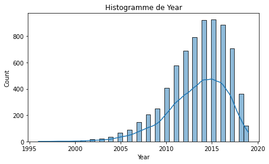

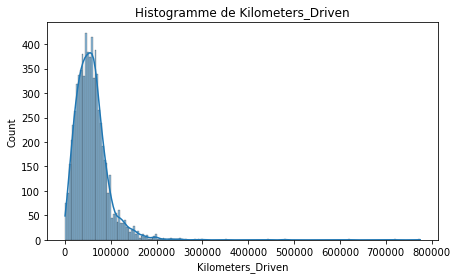

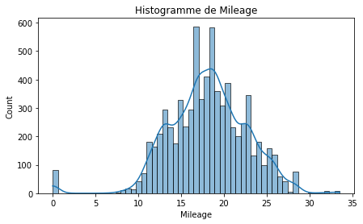

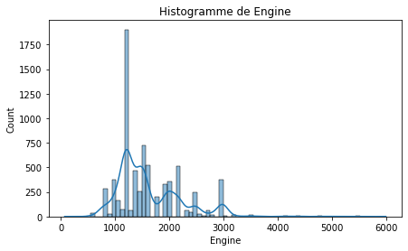

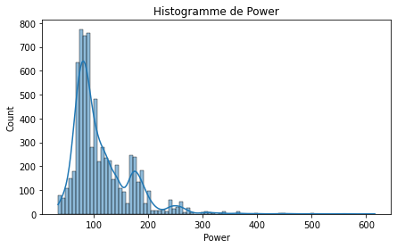

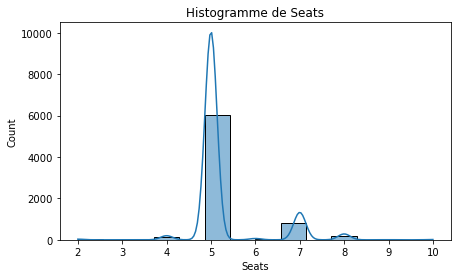

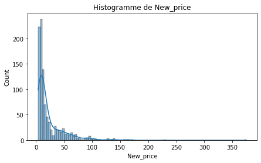

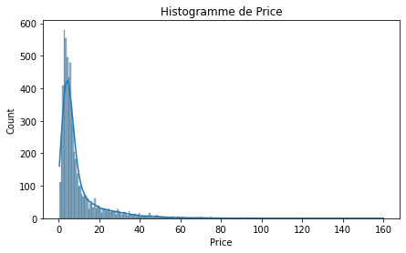

```python
for col in df.select_dtypes(include='number').columns:
    plt.figure(figsize=(7, 4))
    sns.histplot(data=df, x=col, kde=True)
    plt.title(f'Histogramme de {col}')
    plt.show()
```

Observation : The distribution of Price and Kilometers_driven are highly skewed, we can use log transformation on this column to see if that helps normalize the distribution.

```python
df['Price_log'] = np.log(df['Price'])
```

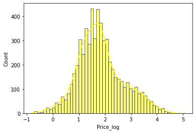

```python
sns.histplot(data = df, x = 'Price_log', kde = True, color ='yellow')
```

```python
df['Kilometers_Driven_log'] = np.log(df['Kilometers_Driven'])
```

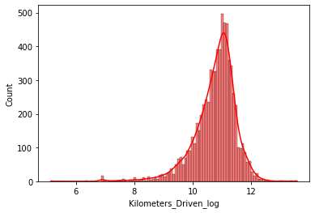

```python
sns.histplot(data = df, x = 'Kilometers_Driven_log', kde = True, color ='red')
```

Observation : The log transformation helps normalize the distribution.

1. Univariate analysis - Categorical Data

[figure not shown]

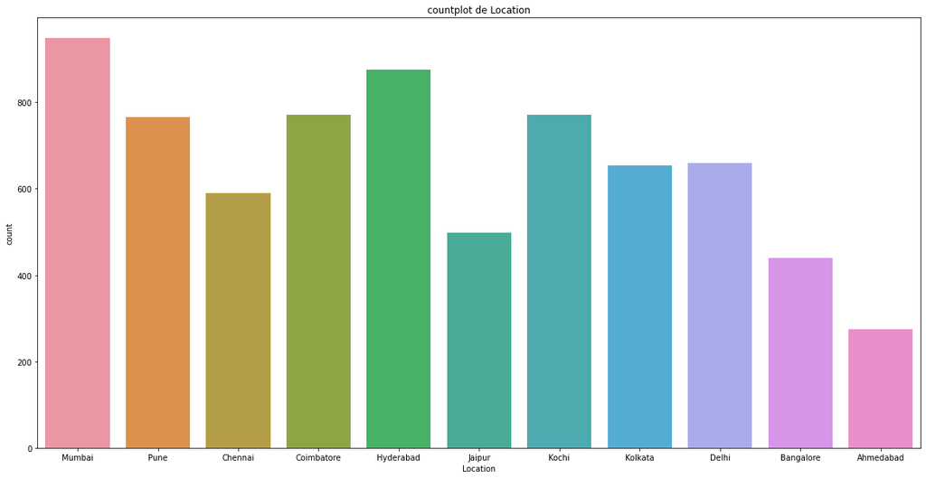

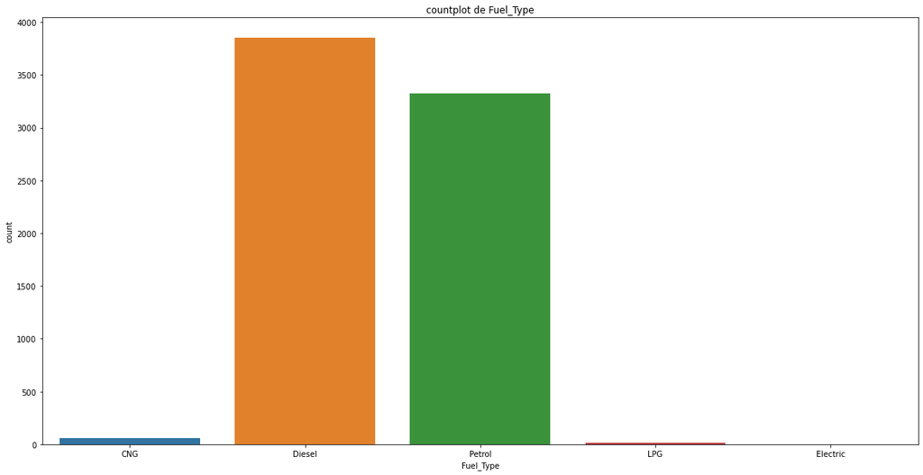

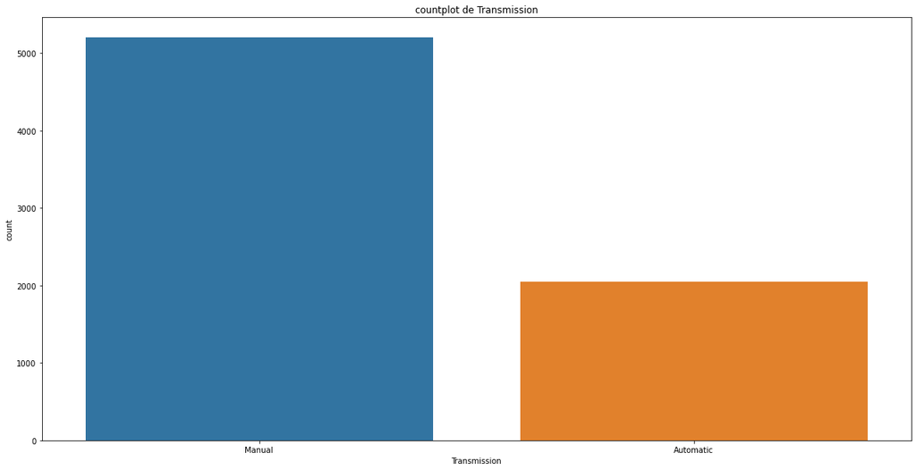

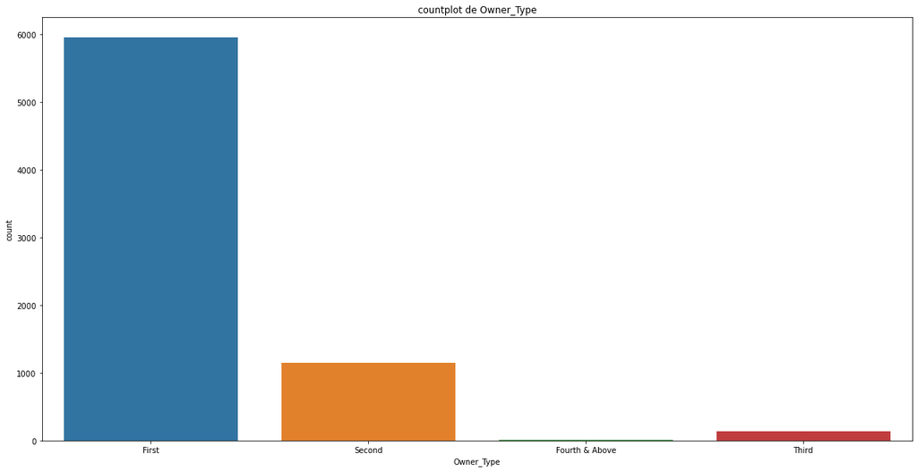

```python
for col in df.select_dtypes(include='object').columns:
    plt.figure(figsize=(20, 10))
    sns.countplot(data=df, x=col)
    plt.title(f'countplot de {col}')
    plt.show()
```

```python
cat_cols= ['Name','Location','Fuel_Type','Transmission','Owner_Type']
for i in cat_cols:
    print(df[i].value_counts(normalize = True))
    print('*'*40)
```

```
Mahindra XUV500 W8 2WD                  0.007584
Maruti Swift VDI                        0.006757
Maruti Swift Dzire VDI                  0.005792
Honda City 1.5 S MT                     0.005378
Maruti Swift VDI BSIV                   0.005102
                                          ...
Tata Manza Aura Plus Quadrajet BS IV    0.000138
Tata Indigo eCS LS (TDI) BS-III         0.000138
Hyundai Grand i10 Era                   0.000138
Ford Figo Diesel                        0.000138
Hyundai Elite i20 Magna Plus            0.000138
Name: Name, Length: 2041, dtype: float64
Mumbai        0.130860
Hyderabad     0.120794
Coimbatore    0.106453
Kochi         0.106453
Pune          0.105488
Delhi         0.091009
Kolkata       0.090182
Chennai       0.081357
Jaipur        0.068809
Bangalore     0.060673
Ahmedabad     0.037921
Name: Location, dtype: float64
Diesel      0.531026
Petrol      0.458494
CNG         0.008549
LPG         0.001655
Electric    0.000276
Name: Fuel_Type, dtype: float64
Manual       0.717595
Automatic    0.282405
Name: Transmission, dtype: float64
First             0.820601
Second            0.158853
Third             0.018891
Fourth & Above    0.001655
Name: Owner_Type, dtype: float64
```

Observations :

```
The 'Name' column comprises 2041 distinct values, with the most prevalent car model being the 'Mahindra XUV500 W8 2WD,' accounting for approximately 0.76% of the cars in the dataset.
```

In the 'Location' column, there are 11 unique values, and the most frequently occurring location is Mumbai, representing about 13.09% of the cars in the dataset.

Regarding the 'Fuel_Type' column, there are 5 distinct values, and Diesel is the most common fuel type, making up approximately 53.10% of the cars in the dataset.

As for the 'Transmission' column, it contains 2 unique values, with the majority being Manual transmission, accounting for around 71.76% of the cars in the dataset.

Finally, the 'Owner_Type' column consists of 4 unique values, and the most prevalent owner type is First, constituting approximately 82.06% of the cars in the dataset.

Bivariate Analysis

1. Scatter plot

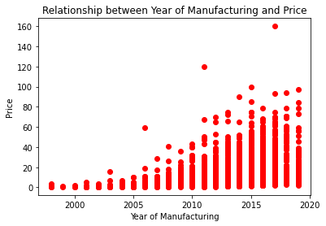

```python
# Create a scatter plot of the relationship between the year of manufacturing and the price of a used car
plt.scatter(df['Year'], df['Price'], color='red')
plt.xlabel('Year of Manufacturing')
plt.ylabel('Price')
plt.title('Relationship between Year of Manufacturing and Price')
plt.show()
```

Observation : There is a positive relationship between the price of the car and the year of the car, as the price of the car increases every year.

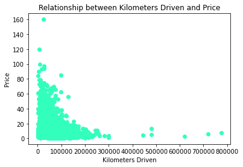

```python
# Create a scatter plot of the relationship between kilometers driven and the price of a used car
plt.scatter(df['Kilometers_Driven'], df['Price'], color='#33FFBD')
plt.xlabel('Kilometers Driven')
plt.ylabel('Price')
plt.title('Relationship between Kilometers Driven and Price')
plt.show()
```

Observation :The relation between kilometers driven and car price is a measure of how much a car has been driven. In general, as the number of kilometers driven increases, the price of the car tends to decrease.

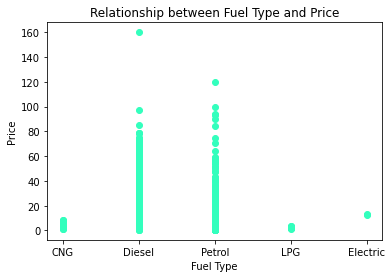

```python
# Create a scatter plot of the relationship between fuel type and the price of a used car
plt.scatter(df['Fuel_Type'], df['Price'], color='#33FFBD')
plt.xlabel('Fuel Type')
plt.ylabel('Price')
plt.title('Relationship between Fuel Type and Price')
plt.show()
```

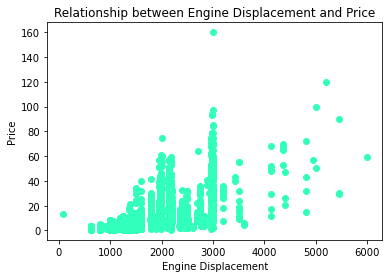

```python
# Create a scatter plot of the relationship between engine displacement and the price of a used car
plt.scatter(df['Engine'], df['Price'], color='#33FFBD')
plt.xlabel('Engine Displacement')
plt.ylabel('Price')
plt.title('Relationship between Engine Displacement and Price')
plt.show()
```

Observation :The relationship between the engine and the price of the car is positively correlated, which means that the car engine is one of the factors that can affect the price of the car. Generally speaking, a more powerful engine increases the price of a car.

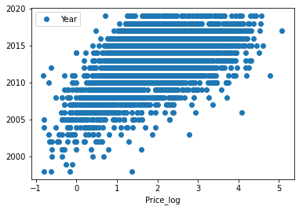

```python
# Let us plot pair plot for the variables 'year' and 'price_log'
df.plot(x = 'Price_log', y = 'Year', style = 'o')
```

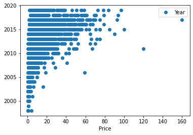

```python
# Let us plot pair plot for the variables 'year' and 'Price'
df.plot(x = 'Price', y = 'Year', style = 'o')
```

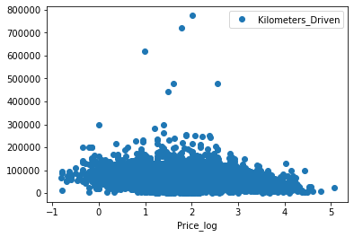

```python
df.plot(x = 'Price_log', y = 'Kilometers_Driven', style = 'o')
```

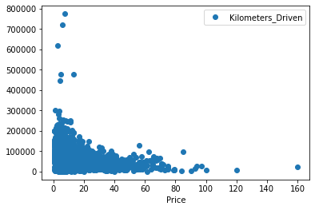

```python
df.plot(x = 'Price', y = 'Kilometers_Driven', style = 'o')
```

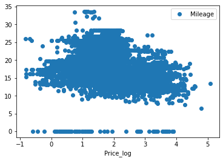

```python
df.plot(x = 'Price_log', y = 'Mileage', style = 'o')
```

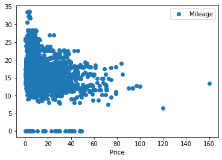

```python
df.plot(x = 'Price', y = 'Mileage', style = 'o')
```

Observation :The mileage driven is negatively correlated with the car price, i.e. the price of the car tends to decrease as the mileage increases. This is because higher mileage indicates that the car is being driven more frequently, which causes greater wear and tear on the engine, transmission and other components

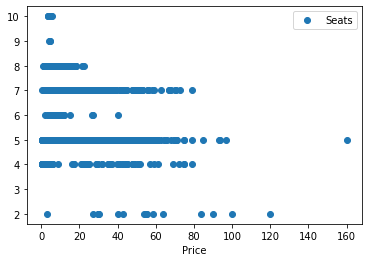

```python
df.plot(x = 'Price', y = 'Seats', style = 'o')
```

1. Heat map

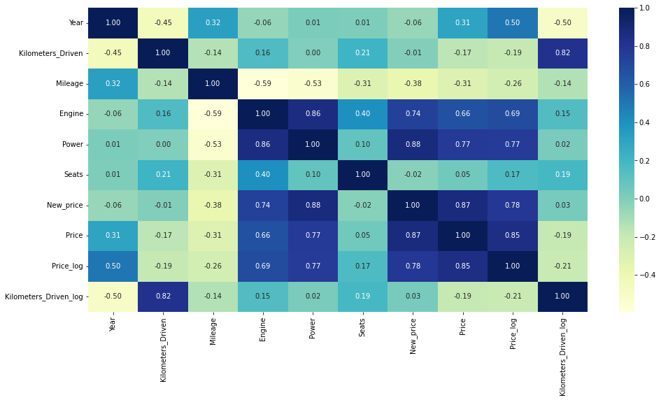

```python
plt.figure(figsize=(16, 8))
sns.heatmap(df.corr(), annot=True, fmt='0.2f', cmap='YlGnBu')
plt.show()
```

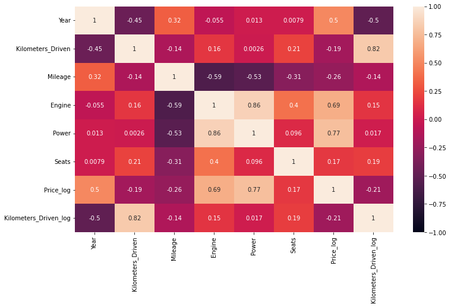

```python
# We can include the log transformation values and drop the original skewed data columns
plt.figure(figsize = (12, 7))

# Specify the columns to drop
cols_to_drop = ['Price', 'New_price']

sns.heatmap(df.drop(cols_to_drop, axis=1).corr(), annot=True, vmin=-1, vmax=1)

plt.show()
```

1. Box plot

```python
# Let us write a function that will help us create boxplot w.r.t Price for any input categorical variable.
# This function takes the categorical column as the input and returns the boxplots for the variable.
def boxplot(z):

    plt.figure(figsize = (12, 5)) # Setting size of boxplot

    sns.boxplot(x = z, y = df['Price']) # Defining x and y

    plt.show()

    plt.figure(figsize = (12, 5))

    plt.title('Without Outliers')

    sns.boxplot(x = z, y = df['Price'], showfliers = False) # Turning off the outliers

    plt.show()
```

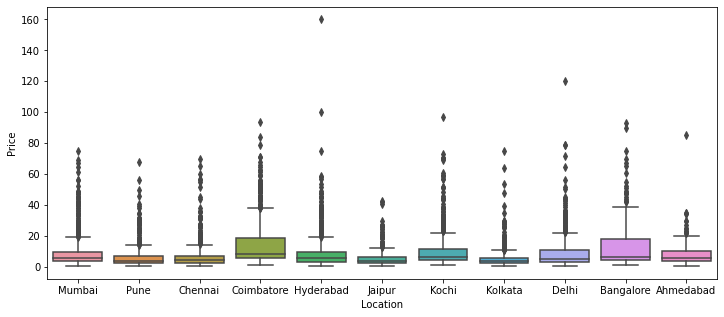

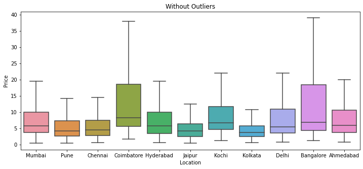

```python
# Box Plot: Price vs Location
boxplot(df['Location'])
```

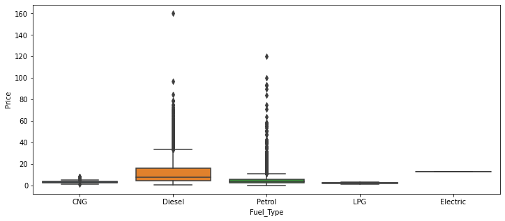

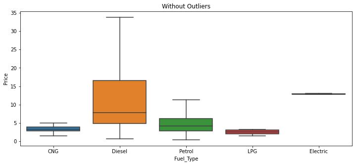

```python
# Box Plot: Price vs Fuel_type
boxplot(df['Fuel_Type'])
```

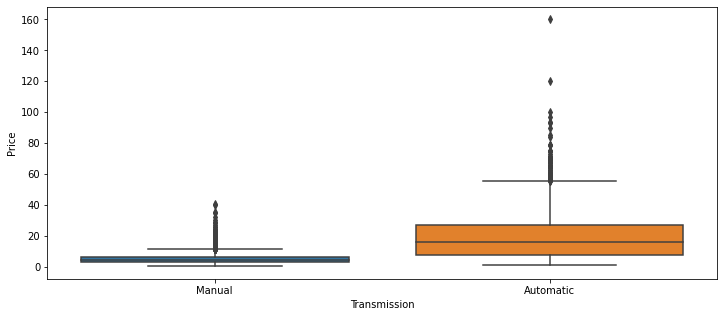

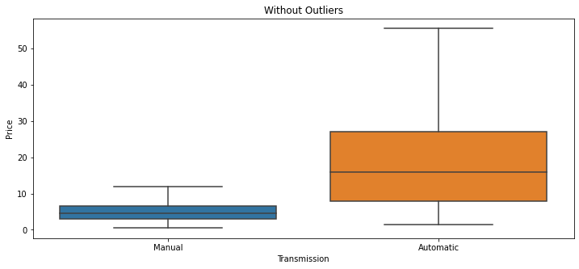

```python
# Box Plot: Price vs Transmission
boxplot(df['Transmission'])
```

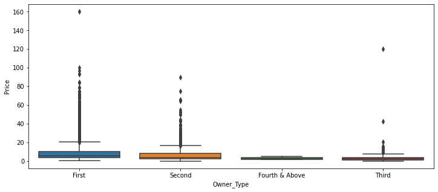

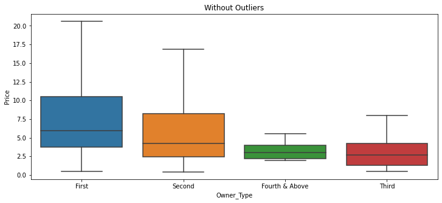

```python
# Box Plot: Price vs Owner_Type
boxplot(df['Owner_Type'])
```

Feature Engineering

Think about it: The Name column in the current format might not be very useful in our analysis. Since the name contains both the brand name and the model name of the vehicle, the column would have too many unique values to be useful in prediction. Can we extract that information from that column?

Hint: With 2041 unique names, car names are not going to be great predictors of the price in our current data. But we can process this column to extract important information for example brand name.

```python
# Extract Brand Names
df["Brand"] = df["Name"].apply(lambda x: x.split(" ")[0].lower())
```

```python
# Extract Model Names
df["Model"] = df["Name"].apply(lambda x: x.split(" ")[1].lower())
```

```python
df.head(5)
```

|  | Name | Location | Year | Kilometers_Driven | Fuel_Type | Transmission | Owner_Type | Mileage | Engine | Power | Seats | New_price | Price | Price_log | Kilometers_Driven_log | Brand | Model |
| --- | --- | --- | --- | --- | --- | --- | --- | --- | --- | --- | --- | --- | --- | --- | --- | --- | --- |
| 0 | Maruti Wagon R LXI CNG | Mumbai | 2010 | 72000 | CNG | Manual | First | 26.60 | 998.0 | 58.16 | 5.0 | NaN | 1.75 | 0.559616 | 11.184421 | maruti | wagon |
| 1 | Hyundai Creta 1.6 CRDi SX Option | Pune | 2015 | 41000 | Diesel | Manual | First | 19.67 | 1582.0 | 126.20 | 5.0 | NaN | 12.50 | 2.525729 | 10.621327 | hyundai | creta |
| 2 | Honda Jazz V | Chennai | 2011 | 46000 | Petrol | Manual | First | 18.20 | 1199.0 | 88.70 | 5.0 | 8.61 | 4.50 | 1.504077 | 10.736397 | honda | jazz |
| 3 | Maruti Ertiga VDI | Chennai | 2012 | 87000 | Diesel | Manual | First | 20.77 | 1248.0 | 88.76 | 7.0 | NaN | 6.00 | 1.791759 | 11.373663 | maruti | ertiga |
| 4 | Audi A4 New 2.0 TDI Multitronic | Coimbatore | 2013 | 40670 | Diesel | Automatic | Second | 15.20 | 1968.0 | 140.80 | 5.0 | NaN | 17.74 | 2.875822 | 10.613246 | audi | a4 |

Missing value treatment

```python
df.dropna(inplace=True)
```

```python
df.isnull().sum()
```

```
Name                     0
Location                 0
Year                     0
Kilometers_Driven        0
Fuel_Type                0
Transmission             0
Owner_Type               0
Mileage                  0
Engine                   0
Power                    0
Seats                    0
New_price                0
Price                    0
Price_log                0
Kilometers_Driven_log    0
Brand                    0
Model                    0
dtype: int64
```

```python
df.isnull().sum().sum()
```

```
0
```

Building Various Models

What we want to predict is the "Price". We will use the normalized version 'price_log' for modeling. Before we proceed to the model, we'll have to encode categorical features. We will drop categorical features like Name. We'll split the data into train and test, to be able to evaluate the model that we build on the train data. Build Regression models using train data. Evaluate the model performance.

Split the Data

Step1: Seperating the indepdent variables (X) and the dependent variable (y).

Step2: Encode the categorical variables in X using pd.dummies.

Step3: Split the data into train and test using train_test_split.

```python
# Step-1
X = df.drop(['Name','Price','Price_log','Kilometers_Driven'], axis = 1)

y = df[["Price_log", "Price"]]
```

```python
# Step-2 Use pd.get_dummies(drop_first = True)
X = pd.get_dummies(X, drop_first = True)
```

```python
# Step-3 Splitting data into training and test set:
from sklearn.model_selection import train_test_split
```

```python
X_train, X_test, y_train, y_test = train_test_split(X, y, test_size = 0.3, random_state = 1)

print(X_train.shape, X_test.shape)
```

```
(4112, 256) (1763, 256)
```

```python
# Let us write a function for calculating r2_score and RMSE on train and test data
# This function takes model as an input on which we have trained particular algorithm
# The categorical column as the input and returns the boxplots and histograms for the variable

def get_model_score(model, flag = True):
    '''
    model : regressor to predict values of X

    '''
    # Defining an empty list to store train and test results
    score_list = []

    pred_train = model.predict(X_train)

    pred_train_ = np.exp(pred_train)

    pred_test = model.predict(X_test)

    pred_test_ = np.exp(pred_test)

    train_r2 = metrics.r2_score(y_train['Price'], pred_train_)

    test_r2 = metrics.r2_score(y_test['Price'], pred_test_)

    train_rmse = metrics.mean_squared_error(y_train['Price'], pred_train_, squared = False)

    test_rmse = metrics.mean_squared_error(y_test['Price'], pred_test_, squared = False)

    # Adding all scores in the list
    score_list.extend((train_r2, test_r2, train_rmse, test_rmse))

    # If the flag is set to True then only the following print statements will be dispayed, the default value is True
    if flag == True:

        print("R-sqaure on training set : ", metrics.r2_score(y_train['Price'], pred_train_))

        print("R-square on test set : ", metrics.r2_score(y_test['Price'], pred_test_))

        print("RMSE on training set : ", np.sqrt(metrics.mean_squared_error(y_train['Price'], pred_train_)))

        print("RMSE on test set : ", np.sqrt(metrics.mean_squared_error(y_test['Price'], pred_test_)))

    # Returning the list with train and test scores
    return score_list
```

For Regression Problems, some of the algorithms used are :

1) Linear Regression

2) Ridge / Lasso Regression

3) Decision Trees

4) Random Forest

1) Linear Regression

```python
# Import Linear Regression from sklearn
from sklearn.linear_model import LinearRegression
from sklearn import metrics
```

```python
# Create a linear regression model
lr = LinearRegression()
```

```python
# Fit linear regression model
lr.fit(X_train, y_train['Price_log'])
```

```
LinearRegression()
```

```python
# Get score of the model
LR_score = get_model_score(lr)
```

```
R-sqaure on training set :  0.9375319239584831
R-square on test set :  0.9099268118619476
RMSE on training set :  2.892368003595034
RMSE on test set :  3.107369532667119
```

Observation : In this case, an R² of 0.938 on the training set and 0.910 on the test set suggests that the model explains about 94% of the variance on the training set and about 91% on the of testing. These high values of R² indicate that the model explains much of the variance in the data, which is a good indication of the goodness of fit.

```python
# Import Statsmodels
import statsmodels.api as sm

# Statsmodel api does not add a constant by default. We need to add it explicitly
x_train = sm.add_constant(X_train)

# Add constant to test data
x_test = sm.add_constant(X_test)

def build_ols_model(train):

    # Create the model
    olsmodel = sm.OLS(y_train["Price_log"], train)

    return olsmodel.fit()


# Fit linear model on new dataset
olsmodel1 = build_ols_model(x_train)

print(olsmodel1.summary())
```

```
                            OLS Regression Results
==============================================================================
Dep. Variable:              Price_log   R-squared:                       0.961
Model:                            OLS   Adj. R-squared:                  0.958
Method:                 Least Squares   F-statistic:                     426.3
Date:                Fri, 04 Aug 2023   Prob (F-statistic):               0.00
Time:                        00:24:46   Log-Likelihood:                 1348.8
No. Observations:                4112   AIC:                            -2250.
Df Residuals:                    3888   BIC:                            -833.6
Df Model:                         223
Covariance Type:            nonrobust
=============================================================================================
                                coef    std err          t      P>|t|      [0.025      0.975]
---------------------------------------------------------------------------------------------
const                      -205.2775      2.912    -70.490      0.000    -210.987    -199.568
Year                          0.1076      0.001     71.978      0.000       0.105       0.111
Mileage                      -0.0013      0.002     -0.755      0.450      -0.005       0.002
Engine                    -6.701e-05   2.34e-05     -2.868      0.004      -0.000   -2.12e-05
Power                         0.0034      0.000     13.652      0.000       0.003       0.004
Seats                         0.0252      0.014      1.741      0.082      -0.003       0.054
New_price                     0.0009      0.000      2.686      0.007       0.000       0.001
Kilometers_Driven_log        -0.0642      0.006    -11.543      0.000      -0.075      -0.053
Location_Bangalore            0.1613      0.019      8.430      0.000       0.124       0.199
Location_Chennai              0.0459      0.018      2.493      0.013       0.010       0.082
Location_Coimbatore           0.1210      0.018      6.908      0.000       0.087       0.155
Location_Delhi               -0.0881      0.018     -4.974      0.000      -0.123      -0.053
Location_Hyderabad            0.1395      0.017      8.107      0.000       0.106       0.173
Location_Jaipur              -0.0214      0.019     -1.142      0.254      -0.058       0.015
Location_Kochi               -0.0246      0.017     -1.409      0.159      -0.059       0.010
Location_Kolkata             -0.2240      0.018    -12.496      0.000      -0.259      -0.189
Location_Mumbai              -0.0663      0.017     -3.864      0.000      -0.100      -0.033
Location_Pune                -0.0422      0.018     -2.400      0.016      -0.077      -0.008
Fuel_Type_Diesel              0.0586      0.031      1.872      0.061      -0.003       0.120
Fuel_Type_Electric           -0.1016      0.087     -1.167      0.243      -0.272       0.069
Fuel_Type_LPG                -0.0586      0.082     -0.712      0.476      -0.220       0.103
Fuel_Type_Petrol             -0.0646      0.033     -1.976      0.048      -0.129      -0.001
Transmission_Manual          -0.1054      0.010    -10.202      0.000      -0.126      -0.085
Owner_Type_Fourth & Above    -0.1256      0.084     -1.497      0.134      -0.290       0.039
Owner_Type_Second            -0.0528      0.008     -6.226      0.000      -0.069      -0.036
Owner_Type_Third             -0.1945      0.025     -7.638      0.000      -0.244      -0.145
```

[output cut: 227 more lines]

```
Model_yeti                   -1.0278      0.067    -15.228      0.000      -1.160      -0.895
Model_z4                      0.5068      0.226      2.241      0.025       0.063       0.950
Model_zen                    -0.9689      0.068    -14.289      0.000      -1.102      -0.836
Model_zest                   -0.6288      0.108     -5.840      0.000      -0.840      -0.418
==============================================================================
Omnibus:                     1387.819   Durbin-Watson:                   2.007
Prob(Omnibus):                  0.000   Jarque-Bera (JB):            44563.942
Skew:                          -0.968   Prob(JB):                         0.00
Kurtosis:                      19.011   Cond. No.                     8.69e+19
==============================================================================

Notes:
[1] Standard Errors assume that the covariance matrix of the errors is correctly specified.
[2] The smallest eigenvalue is 3.75e-30. This might indicate that there are
strong multicollinearity problems or that the design matrix is singular.
```

Observation : An R² of 0.961 suggests that the model explains about 96.1% of the variance in the observed data, which is a very strong indication of the goodness of fit of the model. An adjusted R² of 0.958 indicates that the model explains about 95.8% of the variance while taking into account the complexity of the model.

```python
# Retrive Coeff values, p-values and store them in the dataframe
olsmod = pd.DataFrame(olsmodel1.params, columns = ['coef'])

olsmod['pval'] = olsmodel1.pvalues
```

```python
# Filter by significant p-value (pval <= 0.05) and sort descending by Odds ratio

olsmod = olsmod.sort_values(by = "pval", ascending = False)

pval_filter = olsmod['pval']<= 0.05

olsmod[pval_filter]
```

|  | coef | pval |
| --- | --- | --- |
| Fuel_Type_Petrol | -6.460593e-02 | 0.048205 |
| Model_7 | 4.044739e-01 | 0.033715 |
| Model_c-class | -4.684673e-14 | 0.031395 |
| Model_sonata | 2.868639e-01 | 0.030612 |
| Model_sl-class | 1.279536e-13 | 0.026124 |
| ... | ... | ... |
| Brand_mercedes-benz | -7.734965e+00 | 0.000000 |
| Brand_maruti | -8.720731e+00 | 0.000000 |
| Brand_mahindra | -8.727134e+00 | 0.000000 |
| Brand_land | -3.950422e+00 | 0.000000 |
| const | -2.052775e+02 | 0.000000 |

232 rows × 2 columns

```python
# We are looking are overall significant varaible

pval_filter = olsmod['pval']<= 0.05
imp_vars = olsmod[pval_filter].index.tolist()

# We are going to get overall varaibles (un-one-hot encoded varables) from categorical variables
sig_var = []
for col in imp_vars:
    if '' in col:
        first_part = col.split('_')[0]
        for c in df.columns:
            if first_part in c and c not in sig_var :
                sig_var.append(c)


start = '\033[1m'
end = '\033[95m'
print(start+ 'Most overall significant categorical varaibles of LINEAR REGRESSION  are ' +end,':\n', sig_var)
```

```
Most overall significant categorical varaibles of LINEAR REGRESSION  are  :
 ['Fuel_Type', 'Model', 'Location', 'New_price', 'Engine', 'Owner_Type', 'Transmission', 'Kilometers_Driven', 'Kilometers_Driven_log', 'Power', 'Brand', 'Year']
```

2)Build Ridge / Lasso Regression similar to Linear Regression

```python
# Import Ridge/ Lasso Regression from sklearn
from sklearn.linear_model import Ridge
```

```python
# Create a Ridge regression model
ridge = Ridge(alpha=1.0)
```

```python
# Fit Ridge regression model
ridge.fit(X_train, y_train['Price_log'])
```

```
Ridge()
```

```python
# Get score of the model
ridge_score = ridge.score(X_test, y_test['Price_log'])
```

```python
print('Linear Regression R-squared:', lr.score(X_test, y_test['Price_log']))
print('Ridge Regression R-squared:', ridge.score(X_test, y_test['Price_log']))
```

```
Linear Regression R-squared: 0.9512243910725274
Ridge Regression R-squared: 0.9499823991245505
```

3) Decision Tree

```python
# Import Decision tree for Regression from sklearn
from sklearn.tree import DecisionTreeRegressor
```

```python
# Create a decision tree regression model, use random_state = 1
dtree = DecisionTreeRegressor(random_state=1)
```

```python
# Fit decision tree regression model
dtree.fit(X_train, y_train['Price_log'])
```

```
DecisionTreeRegressor(random_state=1)
```

```python
# Get score of the model
Dtree_model = get_model_score(dtree)
```

```
R-sqaure on training set :  0.999996636378286
R-square on test set :  0.8673928463600785
RMSE on training set :  0.021224040081666933
RMSE on test set :  3.7703234774683
```

Observation : In this case, an R² of 0.99 on the training set and 0.867 on the test set suggests that the model explains about 99% of the variance on the training set and about 87% on the of testing. These high values of R² indicate that the model explains much of the variance in the data, which is a good indication of the goodness of fit.

```python
print(pd.DataFrame(dtree.feature_importances_, columns = ["Imp"], index = X_train.columns).sort_values(by = 'Imp', ascending = False))
```

```
                            Imp
Power                  0.641080
Year                   0.227387
Engine                 0.021616
Kilometers_Driven_log  0.016874
Brand_mercedes-benz    0.008426
...                         ...
Model_one              0.000000
Model_b                0.000000
Model_nuvosport        0.000000
Model_beetle           0.000000
Model_freestyle        0.000000

[256 rows x 1 columns]
```

4) Random Forest

```python
# Import Randomforest for Regression from sklearn
from sklearn.ensemble import RandomForestRegressor
```

```python
# Create a Randomforest regression model
rf = RandomForestRegressor(random_state=1)
```

```python
# Fit Randomforest regression model
rf.fit(X_train, y_train['Price_log'])
```

```
RandomForestRegressor(random_state=1)
```

```python
# Get score of the model
rf_score = rf.score(X_test, y_test['Price_log'])
```

```python
# Print important features similar to decision trees
importances = pd.DataFrame(rf.feature_importances_, columns=["Imp"], index=X_train.columns)
print(importances.sort_values(by="Imp", ascending=False))
```

```
                            Imp
Power                  0.638720
Year                   0.227266
Engine                 0.025126
Kilometers_Driven_log  0.017138
Mileage                0.009934
...                         ...
Model_cls-class        0.000000
Model_sl-class         0.000000
Model_redi             0.000000
Model_mux              0.000000
Model_c-class          0.000000

[256 rows x 1 columns]
```

Hyperparameter Tuning: Decision Tree

```python
from sklearn.tree import DecisionTreeRegressor
from sklearn.model_selection import GridSearchCV
from sklearn.metrics import make_scorer, r2_score

# Choose the type of estimator
dtree_tuned = DecisionTreeRegressor(random_state=1)

# Grid of parameters to choose from
parameters = {'max_depth': [2, 4, 6, 8, 10], 'min_samples_split': [2, 4, 6, 8, 10]}

# Type of scoring used to compare parameter combinations
scorer = make_scorer(r2_score)

# Run the grid search
grid_obj = GridSearchCV(dtree_tuned, parameters, scoring=scorer)
grid_obj = grid_obj.fit(X_train, y_train['Price_log'])

# Set the model to the best combination of parameters
dtree_tuned = grid_obj.best_estimator_

# Fit the best algorithm to the data
dtree_tuned.fit(X_train, y_train['Price_log'])
```

```
DecisionTreeRegressor(max_depth=10, min_samples_split=10, random_state=1)
```

```python
# Get score of the dtree_tuned
dtree_tuned_score = dtree_tuned.score(X_test, y_test['Price_log'])
print('Tuned Decision Tree R-squared:', dtree_tuned_score)
```

```
Tuned Decision Tree R-squared: 0.8942259094178132
```

Observation : An R² of 0.89 suggests that the model explains about 89.42% of the variance in the observed data, which is a very strong indication of the goodness of fit of the model

```python
# Print important features of tuned decision tree similar to decision trees
importances = pd.DataFrame(dtree_tuned.feature_importances_, columns=["Imp"], index=X_train.columns)
print(importances.sort_values(by="Imp", ascending=False))
```

```
                            Imp
Power                  0.668257
Year                   0.234079
Engine                 0.020662
Kilometers_Driven_log  0.008915
Brand_mercedes-benz    0.007870
...                         ...
Model_esteem           0.000000
Model_etios            0.000000
Model_evalia           0.000000
Model_f                0.000000
Model_zest             0.000000

[256 rows x 1 columns]
```

Hyperparameter Tuning: Random Forest

```python
from sklearn.ensemble import RandomForestRegressor
from sklearn.model_selection import GridSearchCV
from sklearn.metrics import make_scorer, r2_score

# Choose the type of Regressor
rf_tuned = RandomForestRegressor(random_state=1)

# Define the parameters for Grid to choose from
parameters = {'n_estimators': [10, 50, 100], 'max_depth': [2, 4, 6, 8, 10], 'min_samples_split': [2, 4, 6, 8, 10]}

# Type of scoring used to compare parameter combinations
scorer = make_scorer(r2_score)

# Run the grid search
grid_obj = GridSearchCV(rf_tuned, parameters, scoring=scorer)
grid_obj = grid_obj.fit(X_train, y_train['Price_log'])

# Set the model to the best combination of parameters
rf_tuned = grid_obj.best_estimator_

# Fit the best algorithm to the data
rf_tuned.fit(X_train, y_train['Price_log'])

# Get score of the rf_tuned
rf_tuned_score = rf_tuned.score(X_test, y_test['Price_log'])
print('Tuned Random Forest R-squared:', rf_tuned_score)
```

```
Tuned Random Forest R-squared: 0.9314805288779575
```

```python
# Get score of the model
rf_tuned_score = rf_tuned.score(X_test, y_test['Price_log'])
print('Tuned Random Forest R-squared:', rf_tuned_score)
```

```
Tuned Random Forest R-squared: 0.9314805288779575
```

Observation : An R² of 0.93 suggests that the model explains about 93.14% of the variance in the observed data, which is a very strong indication of the goodness of fit of the model

```python
importances = pd.DataFrame(dtree_tuned.feature_importances_, columns=["Imp"], index=X_train.columns)
print(importances.sort_values(by="Imp", ascending=False))
```

```
                            Imp
Power                  0.668257
Year                   0.234079
Engine                 0.020662
Kilometers_Driven_log  0.008915
Brand_mercedes-benz    0.007870
...                         ...
Model_esteem           0.000000
Model_etios            0.000000
Model_evalia           0.000000
Model_f                0.000000
Model_zest             0.000000

[256 rows x 1 columns]
```

Conclusions and Recommendations

1. Comparison of various techniques and their relative performance based on chosen Metric (Measure of success):

How do different techniques perform? Which one is performing relatively better? Is there scope to improve the performance further?

1. Refined insights:

What are the most meaningful insights relevant to the problem?

1. Proposal for the final solution design:

What model do you propose to be adopted? Why is this the best solution to adopt?

```python
# Defining list of models you have trained
models = [lr, dtree,ridge ,rf,dtree_tuned,rf_tuned]

# Defining empty lists to add train and test results
r2_train = []
r2_test = []
rmse_train = []
rmse_test = []

# Looping through all the models to get the rmse and r2 scores
for model in models:

    # Accuracy score
    j = get_model_score(model, False)

    r2_train.append(j[0])

    r2_test.append(j[1])

    rmse_train.append(j[2])

    rmse_test.append(j[3])
```

```python
comparison_frame = pd.DataFrame({'Model':['Linear Regression','Decision Tree', 'Ridge Regression','Random Forest','Decision Tree Tuned','Random Forest Tuned'],
                                          'Train_r2': r2_train,'Test_r2': r2_test,
                                          'Train_RMSE': rmse_train,'Test_RMSE': rmse_test})
comparison_frame
```

|  | Model | Train_r2 | Test_r2 | Train_RMSE | Test_RMSE |
| --- | --- | --- | --- | --- | --- |
| 0 | Linear Regression | 0.937532 | 0.909927 | 2.892368 | 3.107370 |
| 1 | Decision Tree | 0.999997 | 0.867393 | 0.021224 | 3.770323 |
| 2 | Ridge Regression | 0.931014 | 0.900386 | 3.039511 | 3.267801 |
| 3 | Random Forest | 0.980290 | 0.888994 | 1.624696 | 3.449597 |
| 4 | Decision Tree Tuned | 0.939160 | 0.829896 | 2.854439 | 4.270235 |
| 5 | Random Forest Tuned | 0.959830 | 0.875493 | 2.319409 | 3.653351 |

# Executive Summary

What are the most important findings from the analysis done in Milestone?

1) The analysis focused on evaluating different models to price used cars in the Indian market. We used measures like R-squared and RMSE to see how well these models predict accurately;

5) The model's insights suggest we can set different prices based on what customers want.

What are the key takeaways and What are the key next steps?

Next Steps:

Put the Random Forest model in our pricing system to predict prices; Use the insights from the feature analysis to set prices; Keep the model up-to-date with new data for accuracy; Set prices differently for different customers based on the model's suggestions; Teach teams how to use the model's predictions and insights.

Provide the final proposed model specifications

# Problem and Solution Summary

Summary of the problem. What problem was being solved?

The problem at hand revolves around effectively pricing used cars in the Indian market for our rent car company. The demand for pre-owned cars has been steadily increasing, and it's crucial for us to accurately determine the prices of these cars to remain competitive and cater to customer demands. The challenge lies in considering multiple factors such as brand, model, year of manufacture, mileage, and more, to arrive at optimal pricing.

Reason for the Proposed Solution Design:

What are the key points that describe the final proposed solution design?

Random Forest Model: The chosen model employs an ensemble of decision trees to predict used car prices based on a multitude of features.

Feature Importance Analysis: The model's feature importance analysis will provide insights into which factors have the most significant impact on car prices, guiding our pricing strategy.

Regular Updates: Regular updates of the model with fresh data ensure its relevance and accuracy as market conditions evolve.

Segmentation Strategy: Utilizing the model's insights, we can segment the market based on various factors to tailor pricing strategies to specific customer preferences.

How it would affect the problem/business?

Impact on the Problem/Business:

The adoption of the Random Forest model offers several noteworthy impacts:

Accurate Pricing: The model's ability to consider numerous features simultaneously will lead to more accurate price predictions, reducing the risk of overpricing or underpricing used cars.

Customer Satisfaction: Accurate pricing enhances customer satisfaction by ensuring fairness in pricing, thus fostering trust and loyalty among customers.

Revenue Growth: Optimized pricing is likely to attract more customers, thereby contributing to revenue growth.

Why is this a 'valid' solution that is likely to solve the problem?

The proposed solution is 'valid' due to the following reasons:

Data-Driven Insights: The feature importance analysis offers data-driven insights into the factors driving used car prices, which strengthens our pricing decisions.

# Recommendations for Implementation

What are some key recommendations to implement the solutions?

Model Integration: Integrate the Random Forest model into our pricing system, ensuring that it generates accurate price predictions for each used car based on its features.

Feature Importance Implementation: Utilize the insights from the feature importance analysis to prioritize certain features in our pricing strategy, thereby aligning prices with the most influential factors.

Regular Model Updates: Establish a schedule for regular model updates to incorporate new data, ensuring that the model remains effective and relevant in a dynamic market.

Segmented Pricing Strategies: Implement segmented pricing strategies based on customer preferences and the model's recommendations, tailoring offers to different customer groups.

Employee Training: Provide training to relevant team members on how to interpret and utilize the model's predictions and insights effectively.

What are the key actionable for stakeholders?

Data Team: Continuously update the model with fresh data, monitor its performance, and ensure seamless integration with existing systems.

Pricing Team: Implement the model's predictions in our pricing strategies, and use the feature importance insights to inform pricing decisions.

Marketing Team: Collaborate with the data and pricing teams to tailor marketing campaigns based on segmented pricing strategies.

Customer Support: Communicate the accuracy and fairness of our pricing strategy to customers, enhancing trust and satisfaction.

What is the expected benefit and/or costs?

Benefits:

Accurate Pricing: Improved accuracy in pricing leads to increased customer trust and higher satisfaction. Competitive Edge: Optimized pricing strategies give us a competitive advantage in the market. Revenue Growth: Attracting more customers through fair pricing leads to increased revenue.

Costs:

Implementation Cost: There might be costs associated with integrating the model into existing systems and training team members. Monitoring Cost: Regular monitoring of the model's performance and updates requires resources.

What are the key risks and challenges?

Model Reliability: The model's accuracy heavily relies on the quality and relevance of the data used for training. Inaccurate or biased data could lead to suboptimal predictions.

Changing Market Dynamics: External factors like economic changes or shifts in customer preferences could impact the model's effectiveness.

Model Complexity: The Random Forest model, while powerful, might be complex to interpret for non-technical stakeholders.

What further analysis needs to be done or what other associated problems need to be solved?

Dynamic Pricing: Consider implementing dynamic pricing based on real-time market changes and demand fluctuations.

Customer Segmentation Analysis: Perform an in-depth analysis to understand customer segments and their preferences better.

Feedback Loop: Establish a feedback loop from customers regarding their perceptions of our pricing strategy, enabling continuous improvement.

Leveraging Unstructured Data: Explore the potential of unstructured data, such as customer reviews, to further refine pricing strategies.

Competitor Analysis: Analyze competitors' pricing strategies and assess how our model-driven approach compares.